# Editorial

The ‘Editorial’ article from the 2017-2 issue.

In my editorial for the 2017–1 issue, I concentrated on tabulating the status of this journal with respect to its authors and reviewers (updated tables below). This time, I was prompted by an interesting [blog posting](http://www.bnosac.be/index.php/blog/70-cran-search-based-on-natural-language-processing) by Jan Wijffels of BNOSAC, describing the use of the [*udpipe*](https://CRAN.R-project.org/package=udpipe) package to apply natural language processing (NLP) to the CRAN package database available from `tools::CRAN_package_db()` since the release of R 3.4. The [interactive NLP searcher](http://datatailor.be:9999/app/cran_search) is a dashboard permitting exploration of annotated CRAN package title and description NLP data.

It struck me that an analysis of abstracts of contributed research articles published in the R Journal would now be possible since the introduction of article landing pages earlier this year, because the [website configuration file](https://raw.githubusercontent.com/rjournal/rjournal.github.io/master/_config.yml) containing the abstracts can be read using the [*yaml*](https://CRAN.R-project.org/package=yaml) package. Jan Wijffels kindly and rapidly responded, providing an [R Journal NLP search](http://datatailor.be:9999/app/rjournal_search) tool analogous to the CRAN NLP search tool.

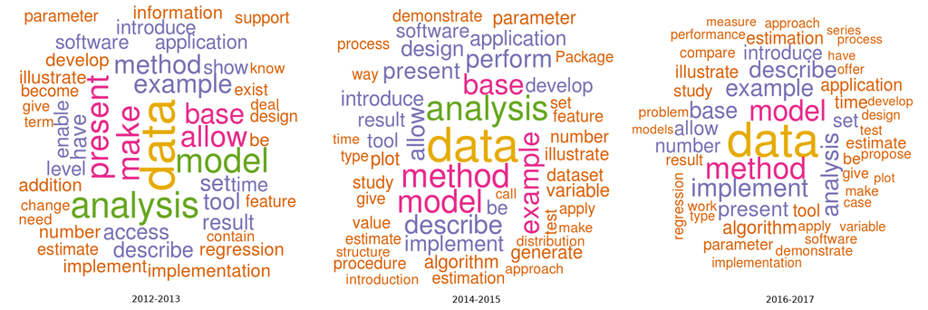

Figure 1 shows total cumulative wordclouds for the last six years in two-year slices, and indicates that we are, broadly, maintaining topical consistency with a sustained focus on data. The search tool permits much more detailed exploration as well, such as term search to supplement web searches on `site:journal.r-project.org`.

While we do not have on-site indexing or searching, a tab has been added for news and notes contributions by issue. In this issue, two new columns are initiated, one for news and notes from [Forwards](https://forwards.github.io/), starting with a report on the useR! 2016 survey (see also [*forwards*](https://CRAN.R-project.org/package=forwards)). The second new column covers teaching R and teaching with R, and kicks off with a note on linking teaching and reproducible research (see also the [*revisit* package](https://github.com/matloff/revisit)). Progress in answering Heather Turner’s appeal to help useRs navigate their way through the R world (editorial, 2011–1) is at best incremental, but progress none the less. A year later, Martyn Plummer pointed out (editorial, 2012–1) that “it is worth spending some time browsing these sections in order to catch up on changes you may have missed.”

From the publication of this issue, fuller benefits from the introduction of landing pages may be realised through the addition of citation page metadata tags, permitting search engines to index contributed research articles more efficiently, thanks to a suggestion by Carl Boettiger. We expect to begin providing DOI for published contributed research articles during 2018 as a further step towards increasing the visibility of the valuable work published here.

We have already added links for supplementary matter (typically reproduction code) on article landing pages, for articles published in this issue. Since the beginning of 2017, submissions were expected to provide scripts permitting reviewers to run code without copying from the manuscript, but previously this was only exceptionally the case, so it may not be practical to provide supplementary matter for articles published in earlier issues.

The wisdom of the editors in choosing to consolidate, and become a listed journal (see Peter Dalgaard’s editorial in 2010–1) is manifest in our current standing in Journal Citation Reports, with a 2016 impact factor of $1.075$, and a five-year score of $2.114$. The steps being taken by the editors and the R Foundation should enhance the discoverability and impact of work published here. It is fair to repeat from the 2010–1 editorial that “we need to show that we have a solid scientific standing with good editorial standards, giving submissions fair treatment and being able to publish on time.”

Table 1: Submission outcomes 2009–2017, by year of submission.

|  | 2009 | 2010 | 2011 | 2012 | 2013 | 2014 | 2015 | 2016 | 2017 |
| --- | --- | --- | --- | --- | --- | --- | --- | --- | --- |
| Published | 26 | 26 | 26 | 22 | 31 | 36 | 51 | 74 | 24 |
| Rejected | 11 | 14 | 11 | 24 | 29 | 32 | 53 | 68 | 55 |
| Under review | 0 | 0 | 0 | 0 | 0 | 0 | 0 | 2 | 65 |
| Total | 37 | 40 | 37 | 46 | 60 | 68 | 104 | 144 | 144 |

Table 2: Published contributed articles 2009–2017, by year of publication.

|  | 2009 | 2010 | 2011 | 2012 | 2013 | 2014 | 2015 | 2016 | 2017 |
| --- | --- | --- | --- | --- | --- | --- | --- | --- | --- |
| Page count | 109 | 123 | 123 | 136 | 362 | 358 | 479 | 895 | 1023 |
| Article count | 18 | 18 | 20 | 18 | 35 | 33 | 36 | 62 | 68 |
| Average length | 6.1 | 6.8 | 6.2 | 7.6 | 10.3 | 10.8 | 13.3 | 14.4 | 15.0 |

Table 3: Median day count from acknowledgement to acceptance and online publication 2013–2017, by year of publication.

|  | 2013 | 2014 | 2015 | 2016 | 2017 |
| --- | --- | --- | --- | --- | --- |
| Median | 347.0 | 225.5 | 212.5 | 212.0 | 244.0 |

### 1 CRAN packages used

udpipe, yaml, forwards

### 2 CRAN Task Views implied by cited packages

NaturalLanguageProcessing, WebTechnologies